# Лабораторная работа №14

Партиции, файловые системы, монтирование

Юсупова К. Р.

Российский университет дружбы народов, Москва, Россия

# Информация

## Докладчик

- Юсупова Ксения Равилевна
- Российский университет дружбы народов
- Номер студенческого билета- 1132247531
- [1132247531@pfur.ru]

# Вводная часть

## Цель работы

Получить навыки создания разделов на диске и файловых систем. Получить навыки монтирования файловых систем

# Выполнение лабораторной работы

Добавили к нашей виртуальной машине два диска размером 512 МБ. Для добавления диска в VirtualBox для нашей виртуальной машины нажали в меню Настроить , выбрали Носители , затем на контроллере SATA нажали «Добавить жёсткий диск». В открывшемся окне нажали «Создать образ диска», в следующем окне выбрали VDI и нажмали Далее , затем отметили «Динамический виртуальный жёсткий диск» и нажали Далее , указали месторасположение диска и его название (disk1.vdi или disk2.vdi), а также его размер — 512 МБ, нажали Создать . В окне выбора жёсткого диска встали на обозначение созданного диска и нажали Выбрать . Для добавления второго диска размером 512 МБ к контроллеру SATA повторили указанные выше действия.

[figure not shown]

Выполнили задание из раздела 14.4.1. (Создание виртуальных носителей)

## Выполнение лабораторной работы

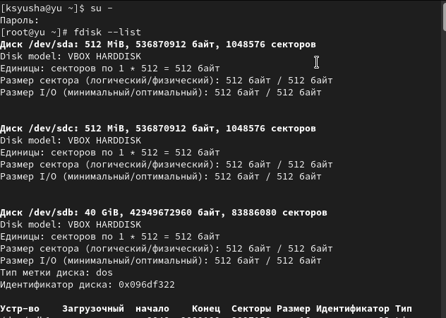

Проверка добавленных дисков командой fdisk –list)

## Выполнение лабораторной работы

Запустили fdisk для работы с диском /dev/sda, получили справку по командам, просмотрели текущее состояние диска командой p.

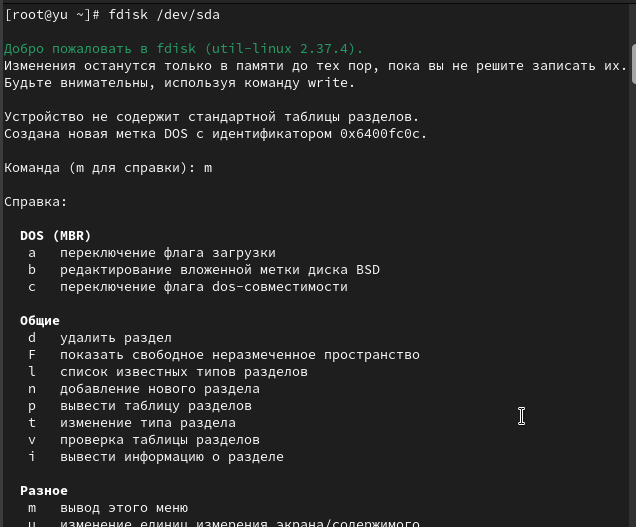

Получение справки и просмотр состояния диска в fdisk

## Выполнение лабораторной работы

Приступили к созданию разделов MBR на диске /dev/sda с помощью утилиты fdisk. Создали основной раздел размером 100 MiB, приняв все значения по умолчанию: тип раздела p (основной), номер раздела 1, первый сектор 2048, последний сектор +100M. Приняли тип раздела по умолчанию Linux (83) и записали изменения на диск командой w

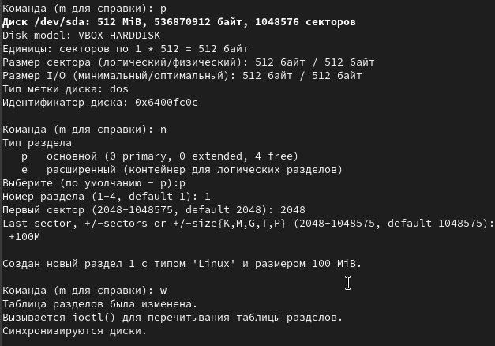

Создание основного раздела MBR на диске /dev/sda

## Выполнение лабораторной работы

Сравнили вывод команды fdisk -l /dev/sda с выводом команды cat /proc/partitions. Команда fdisk показывает подробную информацию о диске и его разделах с указанием типов, начальных и конечных секторов, размеров в понятных единицах, тогда как cat /proc/partitions отображает информацию из памяти ядра в виде сырых данных с указанием major/minor номеров устройств и размеров в блоках. Записали изменения в таблицу разделов ядра командой partprobe /dev/sda.

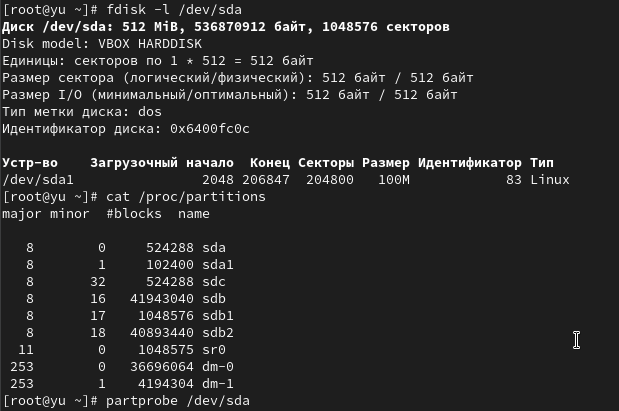

Сравнение выводов fdisk и cat /proc/partitions

## Выполнение лабораторной работы

Вернулись в fdisk для создания логических разделов на том же диске /dev/sda. Создали расширенный раздел, который занял всю оставшуюся часть диска, затем внутри расширенного раздела создали логический раздел размером 101 MiB. Записали изменения и обновили таблицу разделов ядра.

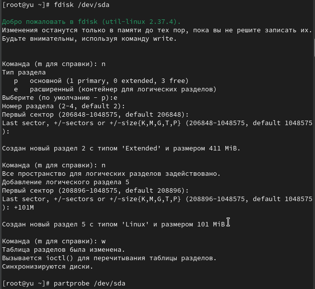

Создание расширенного и логического разделов

## Выполнение лабораторной работы

Просмотрели информацию о добавленных разделах через cat /proc/partitions и fdisk –list /dev/sda, убедившись в правильности созданных разделов: /dev/sda1 (основной), /dev/sda2 (расширенный) и /dev/sda5 (логический).

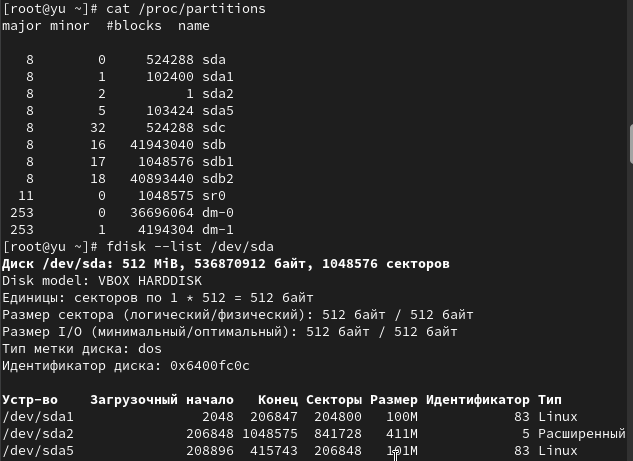

Проверка созданных разделов на диске /dev/sda

## Выполнение лабораторной работы

Создали раздел подкачки на диске /dev/sda. Добавили логический раздел размером 100 MiB, изменили его тип на Linux swap (82), записали изменения и обновили таблицу разделов.

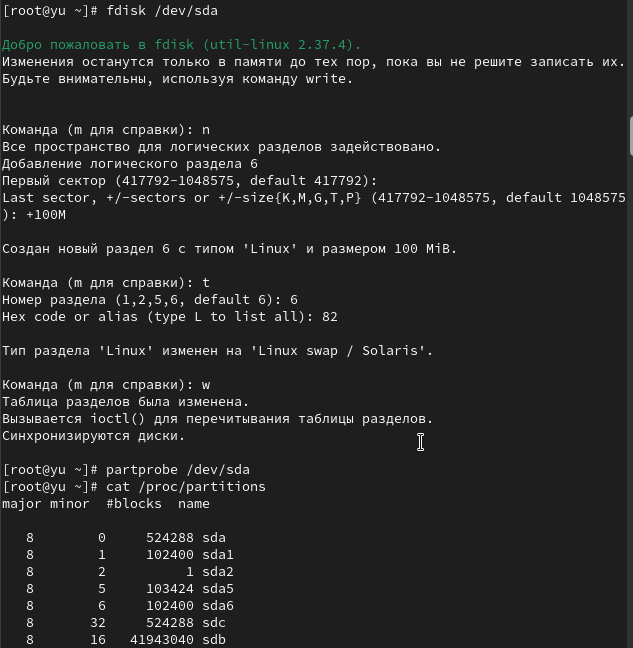

Создание раздела подкачки

## Выполнение лабораторной работы

Отформатировали раздел подкачки командой mkswap /dev/sda6, активировали его с помощью swapon /dev/sda6 и проверили размер пространства подкачки командой free -m. Проверили, что раздел подкачки создан и активирован: fdisk –list /dev/sda показал наличие раздела /dev/sda6 типа Linux swap, а free -m отобразил увеличенный общий объем swap памяти.

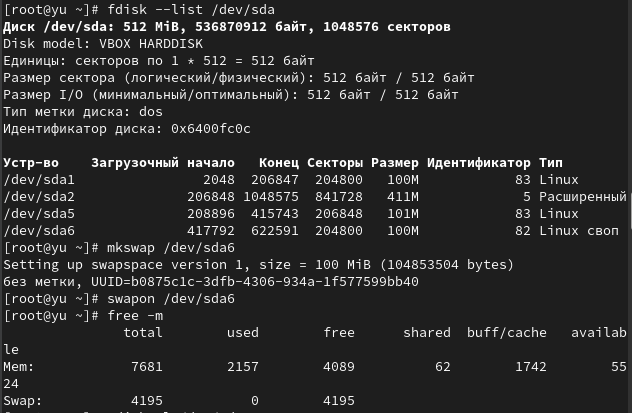

Форматирование и активация раздела подкачки

## Выполнение лабораторной работы

Перешли к работе со вторым добавленным диском /dev/sdc для создания разделов GPT с помощью gdisk. Посмотрели текущее состояние диска командой gdisk -l /dev/sdc, затем запустили gdisk /dev/sdc и создали раздел GPT размером 100 MiB с типом Linux filesystem (8300). Записали изменения и обновили таблицу разделов.

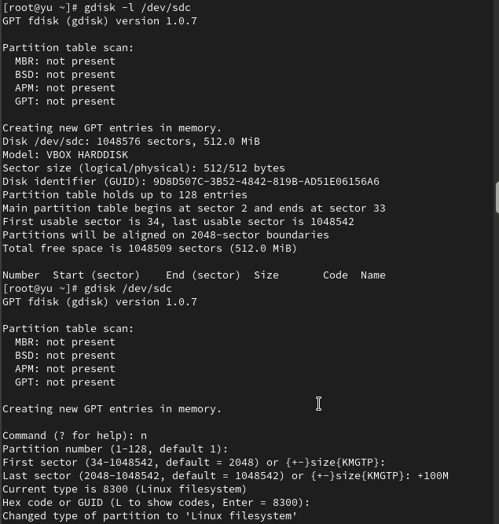

Создание раздела GPT на диске /dev/sdc

## Выполнение лабораторной работы

Проверили создание GPT раздела: gdisk -l /dev/sdc показал наличие раздела /dev/sdc1 размером 100 MiB с типом Linux filesystem, а cat /proc/partitions отобразил соответствующий блок-устройство в системе.

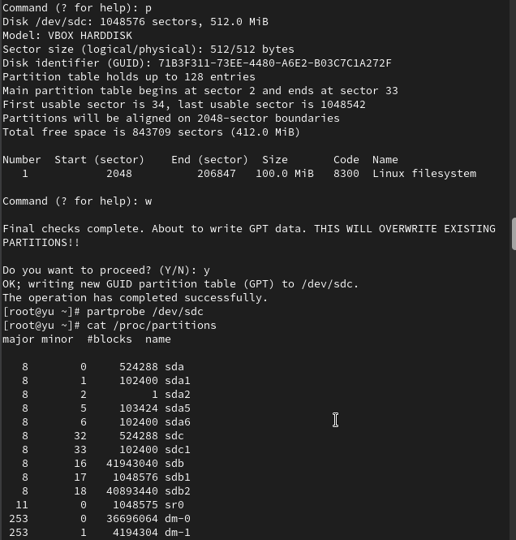

Проверка созданного GPT раздела

## Выполнение лабораторной работы

Выполнили форматирование файловых систем. Для раздела /dev/sda1 создали файловую систему XFS командой mkfs.xfs /dev/sda1 и установили метку файловой системы “xfsdisk” с помощью xfs_admin -L xfsdisk /dev/sda1. Для раздела /dev/sda5 создали файловую систему EXT4 командой mkfs.ext4 /dev/sda5, установили метку “ext4disk” через tune2fs -L ext4disk /dev/sda5 и настроили параметры монтирования по умолчанию с включением списков контроля доступа и расширенных атрибутов пользователя

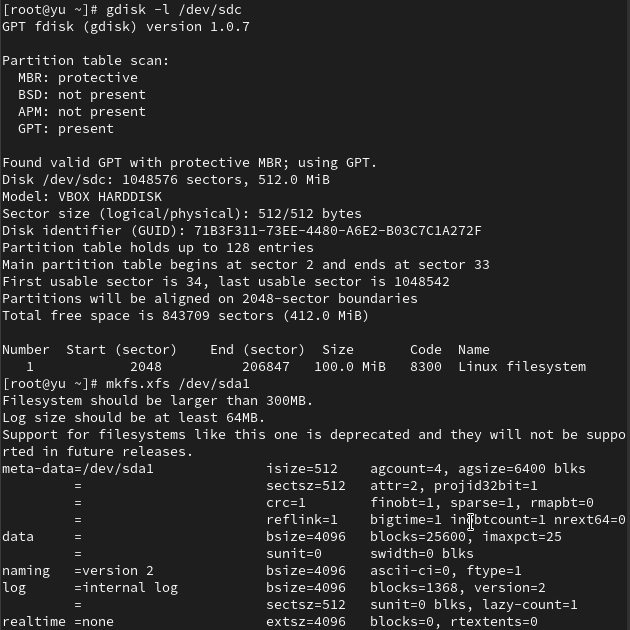

Форматирование файловых систем XFS и EXT4

## Выполнение лабораторной работы

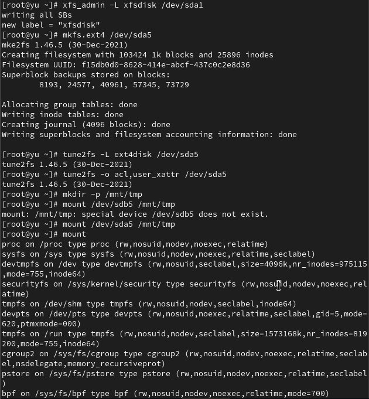

Ручное монтирование и отмонтирование файловой системы

## Выполнение лабораторной работы

Настроили автоматическое монтирование раздела XFS через /etc/fstab. Создали точку монтирования /mnt/data, определили UUID раздела /dev/sda1 командой blkid /dev/sda1, отредактировали файл /etc/fstab, добавив строку с UUID раздела, точкой монтирования /mnt/data и типом файловой системы xfs.

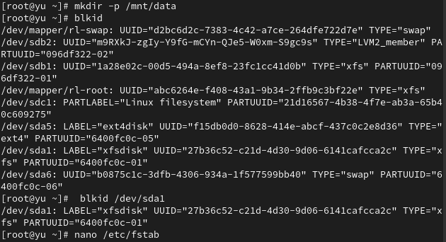

Настройка автоматического монтирования через /etc/fstab

## Выполнение лабораторной работы

Проверили содержимое файла /etc/fstab, убедившись в правильности добавленной записи для автоматического монтирования раздела /dev/sda1 в /mnt/data при загрузке системы.

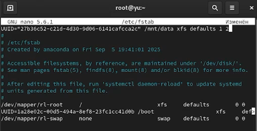

Проверка файла /etc/fstab

## Выполнение лабораторной работы

Применили изменения командой mount -a и проверили монтирование через df -h. Проверили корректность монтирования через /etc/fstab: выполнили mount -a, затем systemctl daemon-reload для обновления systemd, снова mount -a, и df -h показал, что раздел /dev/sda1 успешно смонтирован в /mnt/data.

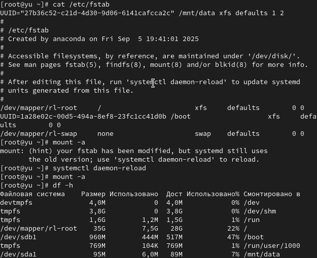

Проверка монтирования через /etc/fstab

# Выполнение самостоятельной работы

Добавили две партации на диск с разбиением GPT (/dev/sdc). Запсутили gdisk /dev/sdc, создали раздел номер 2 размером 100 MiB с типом Linux filesystem (8300) и раздел номер 3 размером 100 Mib c типом Linux swap (8200). Записали изменеия и обновили таблицу разделов

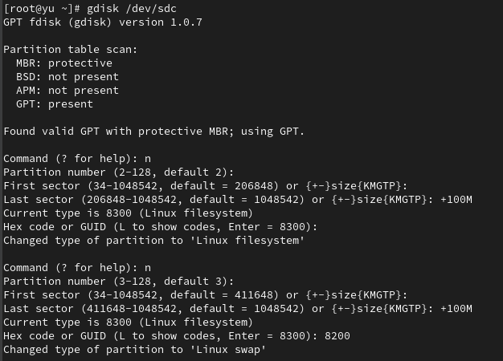

Создание двух разделов GPT на диске /dev/sdc

## Выполнение самостоятельной работы

Проверили созданные разделы: gdisk -l /dev/sdc показал наличие трех разделов /dev/sdc1 (100MiB, Linux filesystem), /dev/sdc2 (100MiB, Linux filesystem) и /dev/sdc3 (100MiB, Linux swap).Cat /proc/partitions отобразил соответствующие блочные устройства в системе

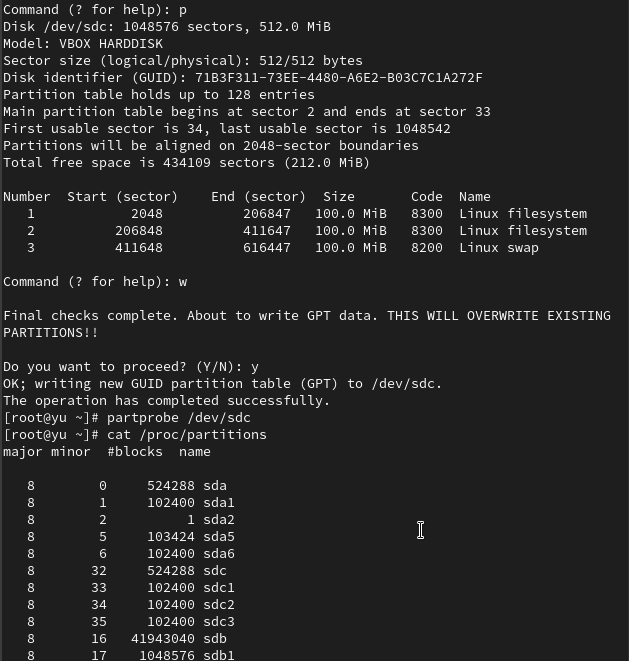

Проверка созданных разделов GPT

## Выполнение самостоятельной работы

Отформатировали созданные разделы: для /dev/sdc2 создали файловую систему ext4 командой mkfs.ext4 /dev/sdc2, для /dev/sdc3 создали раздел подкачки командой mkswap /dev/sdc3. Создали точку монтирования /mnt/data-ext и определили UUID разделов с помощью blkid.

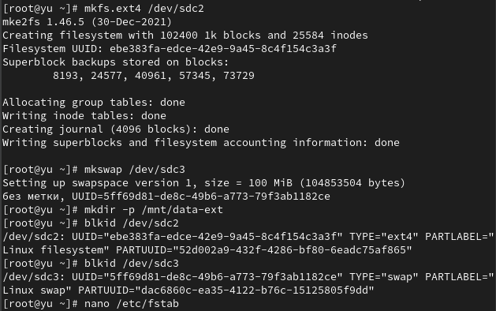

форматирование разделов и получение UUID

## Выполнение самостоятельной работы

Настроили сервер для автоматического монтирования разделов. Отредактирован файл /etc/fstab, добавив строки для автомтического монтирования раздела ext4 в /mnt/data-ext и активации раздела подкачки при заграке системы

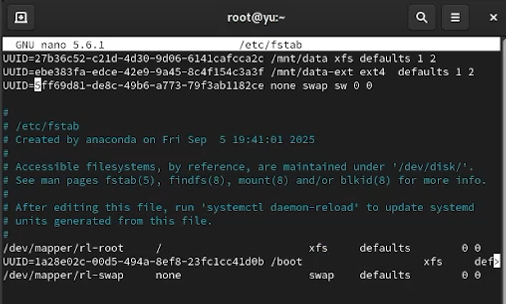

Настройка автоматического монтирования в /etc/fstab

## Выполнение самостоятельной работы

Применили настройки из /etc/fstab командой mount -a, активировали раздел подкачки командой swapon -a. Проверили после перезагрузки системы, что раздел ext4 смонтирован в /mnt/data-ext , раздел подкачки активирован и общий объём памяти увеличен на 100 MiB

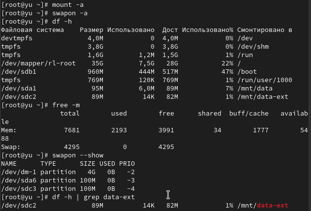

Проверка автоматического монтирования и активации swap

# Выводы

В ходе лабораторной работы мы получили навыки создания разделов на диске и файловых систем; а также получили навыки монтирования файловых систем.